# DATA2002 Report Assignment

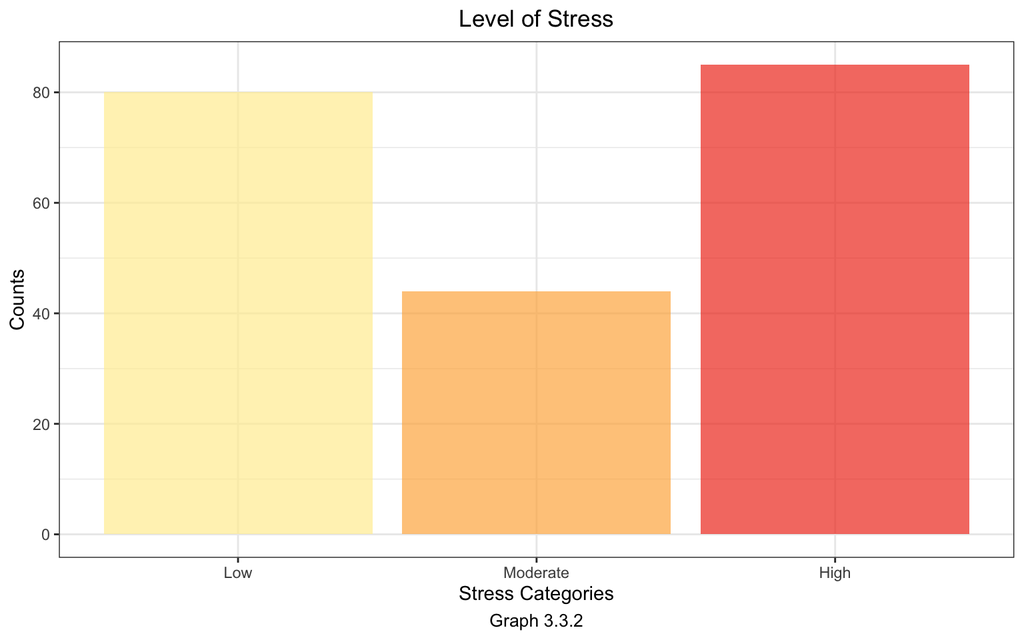

```r
# take 'year' and 'stress_category' data out of the original data (excluding all the missing data from both columns)
year_stress = year_stress %>% filter(!is.na(year), !is.na(stress_category)) %>%
  select(year, stress_category)

# visualization of general 'stress_category' data
year_stress %>% ggplot() +
  aes(x = stress_category, fill = stress_category) +
  geom_bar(alpha = 0.7) +
  labs(x = "Stress Categories", y = "Counts",
       title = "Level of Stress", caption = "Graph 3.3.2") +
  scale_fill_brewer(palette = "YlOrRd",) +
  theme_bw(base_size = 11) +
  theme(plot.title = element_text(hjust = 0.5),
        plot.caption = element_text(hjust = 0.5, size = 10),
        legend.position = "None")
```

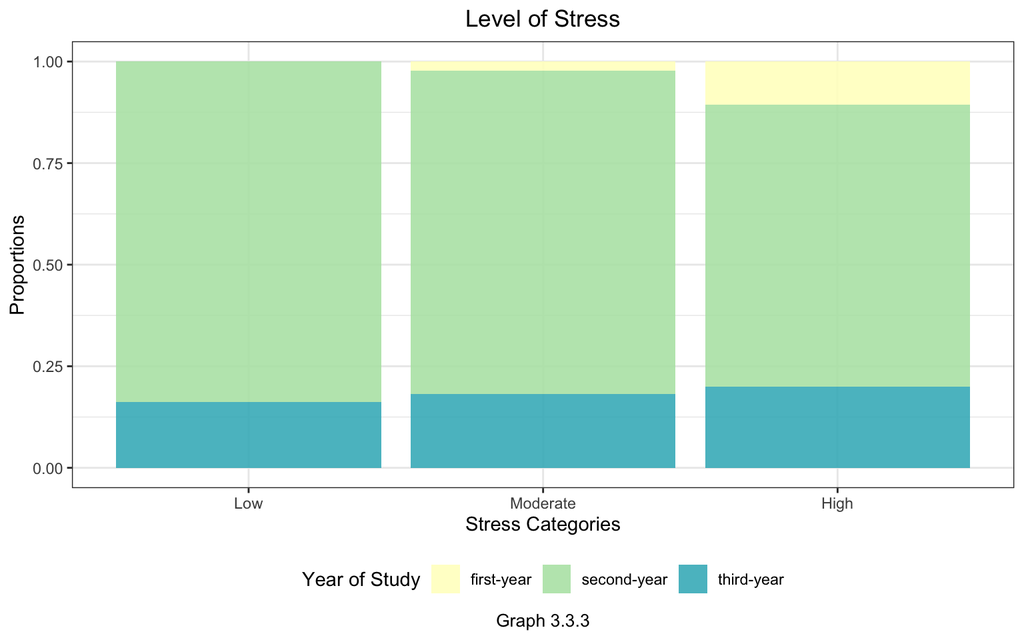

```r
# visualization of 'stress_category' data based on the students' 'year' status
year_stress %>% ggplot() +
  aes(x = stress_category, fill = year) +
  geom_bar(alpha = 0.9, position = "fill") +
  labs(x = "Stress Categories", y = "Proportions", title = "Level of Stress",
       caption = "Graph 3.3.3", fill = "Year of Study") +
  scale_fill_manual(values = c("#FFFFC8", "#B6E4B3", "#41B7C4")) +
  theme_bw(base_size = 11) +
  theme(plot.title = element_text(hjust = 0.5),
        plot.caption = element_text(hjust = 0.5, size = 10),
        legend.position = "bottom")
```

```r
# count the number of students in each corresponding category
year_stress_table = year_stress %>%
  group_by(year, stress_category) %>%
  count() %>%
  tidyr::pivot_wider(id_cols = year,
                     names_from = stress_category,
                     values_from = n) %>%
  mutate(Low = replace_na(Low, 0)) # replace NA with 0

# create a 3 × 3 contingency table (also reorder columns)
year_stress_mat = as.matrix(year_stress_table[, c(4, 2, 3)])
rownames(year_stress_mat) = c("first-year", "second-year", "third-year")

knitr::kable(year_stress_mat, caption = "Table 3.3.1: Contingency Table")
```

Table 3.3.1: Contingency Table

|  | Low | Moderate | High |
| --- | --- | --- | --- |
| first-year | 0 | 1 | 9 |
| second-year | 67 | 35 | 59 |
| third-year | 13 | 8 | 17 |

```r
# check the expected counts of each cell
exp_year_stress = chisq.test(year_stress_mat, correct = FALSE)$expected
knitr::kable(round(exp_year_stress, 1), caption = "Table 3.3.2: Expected Contingency table")
```

Table 3.3.2: Expected Contingency table

|  | Low | Moderate | High |
| --- | --- | --- | --- |
| first-year | 3.8 | 2.1 | 4.1 |
| second-year | 61.6 | 33.9 | 65.5 |
| third-year | 14.5 | 8.0 | 15.5 |

```r
# since some of the expected counts are less than 5 (first-year students)
# perform a Fisher's exact test
fisher.test(year_stress_mat, alternative = "greater")
```

```
##
##  Fisher's Exact Test for Count Data
##
## data:  year_stress_mat
## p-value = 0.01733
## alternative hypothesis: greater
```

## 3.4 Stress Analysis: Does not staying in Australia affect how much Australian students are stressed out?

According to the Department of Education, Skills and Employment (2021), 342,656 international students are enrolled in Australian higher education programs in July 2021. However, the Australian government has closed its borders due to the current COVID-19 pandemic, and as a result, many international students are studying remotely in their home countries. Such a situation may affect the level of stress Australian university students may feel.  
Thus, we will analyze the relationship between students’ study locations and the level of stress international students may feel. As in the previous analyses, the small amount of missing data (less than 1%) have been excluded in this analysis. (please refer to Graph 3.4.1)

A recent survey conducted at Jordan University of Science and Technology found that approximately 32% of 1019 respondents reported that they are more stressed out with remote learning due to various factors such as online exams, or other technical issues. (Elsalem et al., 2020).  
Nevertheless, as this sample data does not completely represent the whole group of international students studying in Australia, further studies based on randomly selected student data from different universities in Australia will yield a more insightful result.

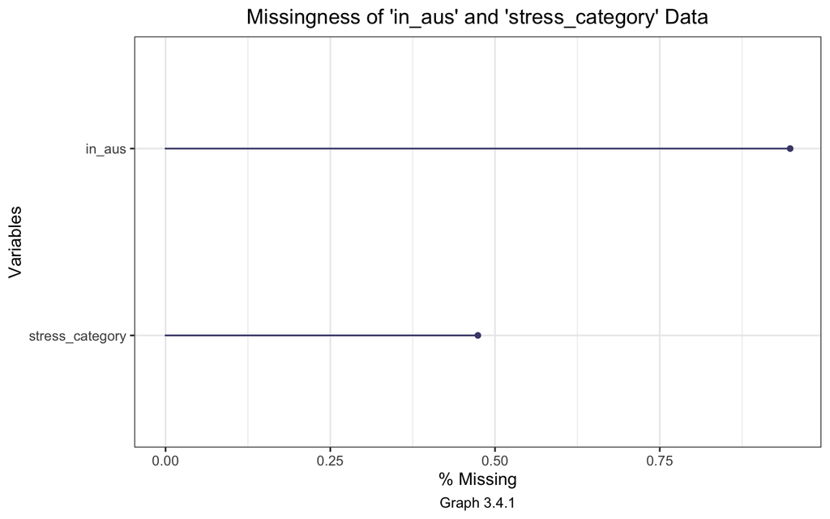

```r
# explore missing data
aus_stress = survey %>% select(in_aus, stress_category)
gg_miss_var(aus_stress, show_pct = TRUE) +
  labs(title = "Missingness of 'in_aus' and 'stress_category' Data",
       caption = "Graph 3.4.1") +
  theme_bw(base_size = 12) +
  theme(plot.title = element_text(hjust = 0.5),
        plot.caption = element_text(hjust = 0.5, size = 10))
```

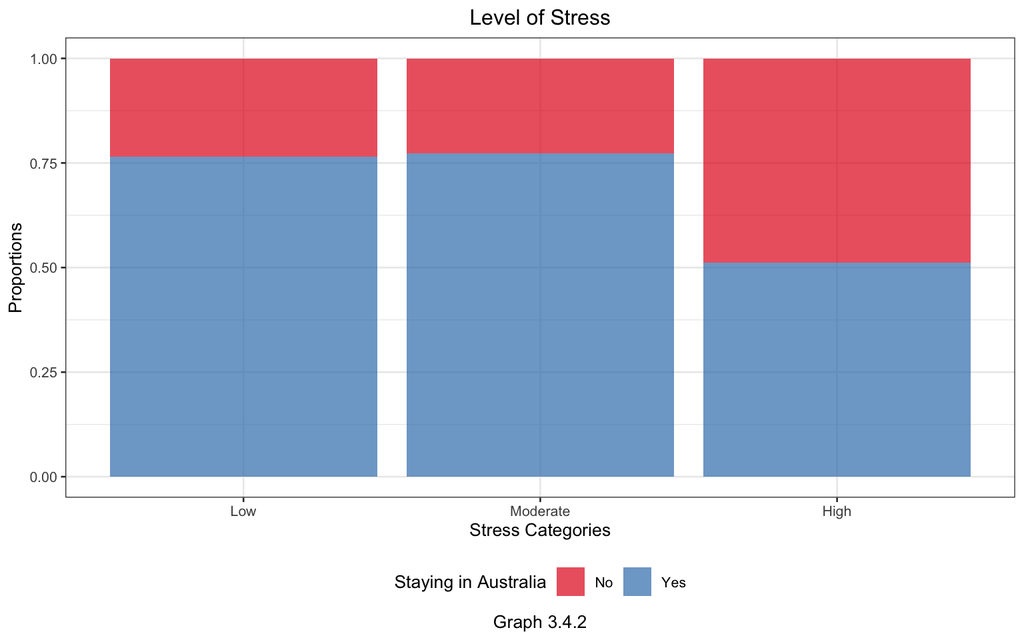

```r
# exclude all the missing data from both columns
aus_stress = aus_stress %>%
  filter(!is.na(in_aus), !is.na(stress_category))

# visualize stress_category data based on the staying status (in Aus vs not in Aus)
aus_stress %>% ggplot() +
  aes(x = stress_category, fill = in_aus) +
  geom_bar(alpha = 0.7, position = "fill") +
  labs(x = "Stress Categories", y = "Proportions", title = "Level of Stress",
       caption = "Graph 3.4.2", fill = "Staying in Australia") +
  scale_fill_brewer(palette = "Set1",) +
  theme_bw(base_size = 10) +
  theme(plot.title = element_text(hjust = 0.5),
        plot.caption = element_text(hjust = 0.5, size = 10),
        legend.position = "bottom")
```

```r
# count the number of students in each corresponding category
aus_stress_table = aus_stress %>%
  group_by(in_aus, stress_category) %>%
  count() %>%
  tidyr::pivot_wider(id_cols = in_aus,
                     names_from = stress_category,
                     values_from = n)

# create a 3 × 2 contingency table (also reorder columns)
aus_stress_mat = as.matrix(aus_stress_table[, c(2, 3, 4)])
rownames(aus_stress_mat) = c("No", "Yes")

knitr::kable(aus_stress_mat, caption = "Table 3.4.1: Contingency Table")
```

Table 3.4.1: Contingency Table

|  | Low | Moderate | High |
| --- | --- | --- | --- |
| No | 19 | 10 | 41 |
| Yes | 62 | 34 | 43 |

```r
# check the expected counts of each cell
exp_aus_stress = chisq.test(aus_stress_mat)$expected
knitr::kable(round(exp_aus_stress, 1), caption = "Table 3.4.2: Expected Contingency Table")
```

Table 3.4.2: Expected Contingency Table

|  | Low | Moderate | High |
| --- | --- | --- | --- |
| No | 27.1 | 14.7 | 28.1 |
| Yes | 53.9 | 29.3 | 55.9 |

```r
# as the contingency table above meets the chi-squared test assumption,
# perform a chi-squared test for independence
chisq.test(aus_stress_mat)
```

```
##
##  Pearson's Chi-squared test
##
## data:  aus_stress_mat
## X-squared = 14.799, df = 2, p-value = 0.0006116
```

## 3.5 Stress Analysis: Are female students more stressed out than male students?

In various topics of study, the existence of gender differences has been a hot potato for many researchers. This analysis aims to analyze the impacts of gender on the level of stress university students feel. In addition to missing data shown in Graph 3.5.1, there is a non-standard data value, “non-binary”. Since there was only one “non-binary” response in the original data, we have also excluded this “non-binary” data.  
Unlike the previous analyses conducted above, we did not categorize the original quantified stress data, as we aim to analyze how the magnitude of the difference in the quantified stress scale is between two gender groups: male and female students. Hence, the hypothesis test we performed in this analysis is a two-sample t-test.

A two-sample t-test is a hypothesis test used to measure the difference between two population parameters, (e.g., a difference in average heights between male and female students), where two sample groups are independent of each other. In this analysis, as we are trying to see whether female students are more stressed than male students, the hypotheses are the following:
$$H_0: \mu_F = \mu_M\ \ \ \ \ \ \ VS \ \ \ \ \ \ \ H_1: \mu_F > \mu_M$$
where $\mu_F$ and $\mu_M$ represent the average stress score of female and male students, respectively.
Before performing a two-sample t-test, we must check an assumption for t-tests: independence and normality. Since the stress scores of female students do not affect the stress scores of male students (and vice versa), these two sample groups are independent of each other.

In terms of normality of data, as t-tests assume that the underlying distribution of sample data is normally distributed (i.e., the distribution is bell-shaped and centered about its mean) we must check whether our sample data of both gender groups are normally distributed. One way of checking normality is to drawing box plots (Graph 3.5.2) and QQ plots (Graph 3.5.3).

As with the previous analyses, we calculate the observed statistic $t_0$ from the sample data of both gender groups, and the p-value measures the proportion of test statistics $T$ that are as or more extreme than $t_0$ (i.e., $P\left(T\ge t_0\right)$).

Such a result suggests that female university students, on average, tend to feel more stress than male students. However, we cannot conclude that female students are more vulnerable to stress than male students because we have not considered any other potential confounding factors that may alter our result. Gao et al. (2020) assert that although there is a large gender difference in the degrees of anxiety and depression, no remarkable gender differences related to stress problems were found.  
Regardless of the existence of gender differences in students’ mental health, it appears that further thorough research is requisite to draw any insightful conclusions about this problem. For instance, if we further divide students into subgroups concerning other factors such as fields of study or living arrangements.

```r
# explore missing data
gender_stress = survey %>%
  select(gender, stress)

knitr::kable(tabyl(survey, gender), caption = "Table 3.5.1: Gender Table")
```

Table 3.5.1: Gender Table

| gender | n | percent | valid_percent |
| --- | --- | --- | --- |
| female | 75 | 0.3554502 | 0.3658537 |
| male | 129 | 0.6113744 | 0.6292683 |
| non-binary | 1 | 0.0047393 | 0.0048780 |
| NA | 6 | 0.0284360 | NA |

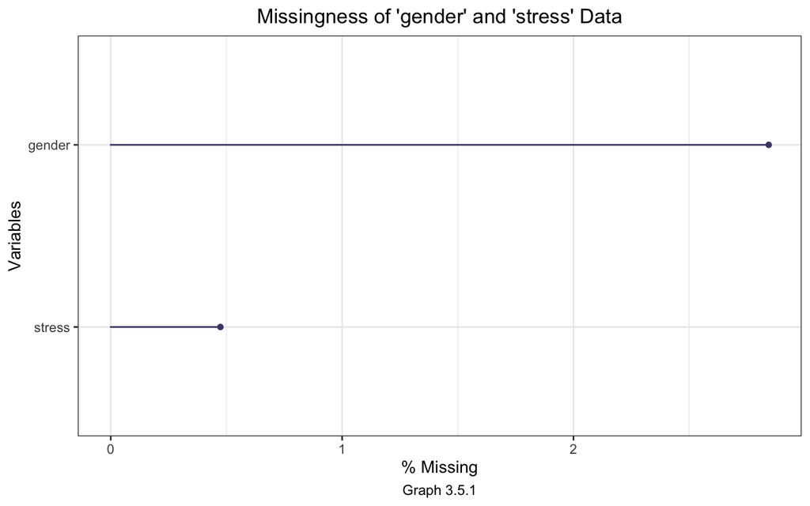

```r
gg_miss_var(gender_stress, show_pct = TRUE) +
  labs(title = "Missingness of 'gender' and 'stress' Data",
       caption = "Graph 3.5.1") +
  theme_bw(base_size = 12) +
  theme(plot.title = element_text(hjust = 0.5),
        plot.caption = element_text(hjust = 0.5, size = 10))
```

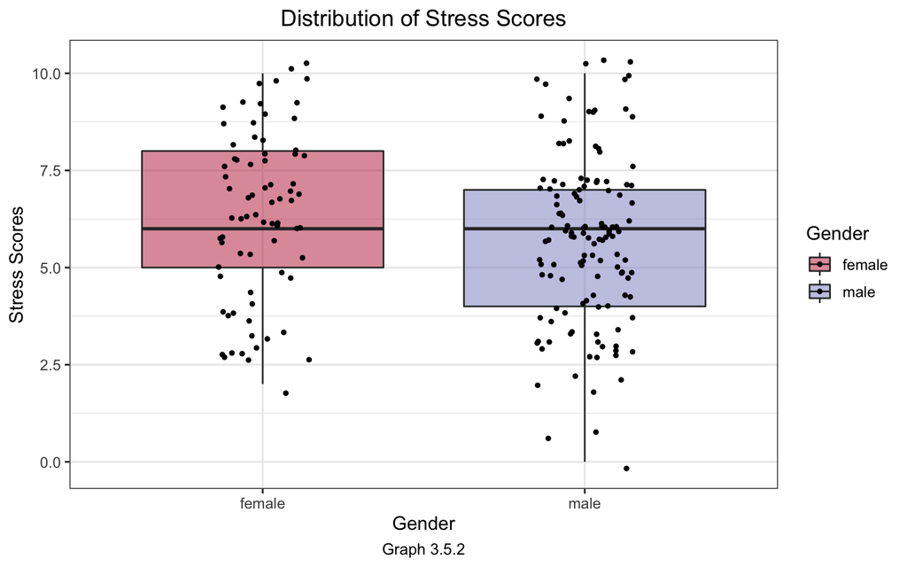

```r
# exclude missing data from both columns
# also exclude "non-binary" gender data
gender_stress = gender_stress %>%
  filter(!is.na(gender), !is.na(stress), gender != "non-binary")

# visualize stress data for two different gender category
gender_stress %>% ggplot() +
  aes(x = gender, y = stress, fill = gender) +
  geom_boxplot(alpha = 0.5, coef = 10) +
  geom_jitter(width = 0.15, size = 1, color = "black") +
  labs(x = "Gender", y = "Stress Scores", title = "Distribution of Stress Scores",
       caption = "Graph 3.5.2", fill = "Gender") +
  scale_fill_manual(values = c("#BE2641", "#888CC7")) +
  theme_bw(base_size = 12) +
  theme(plot.title = element_text(hjust = 0.5),
        plot.caption = element_text(hjust = 0.5, size = 10))
```

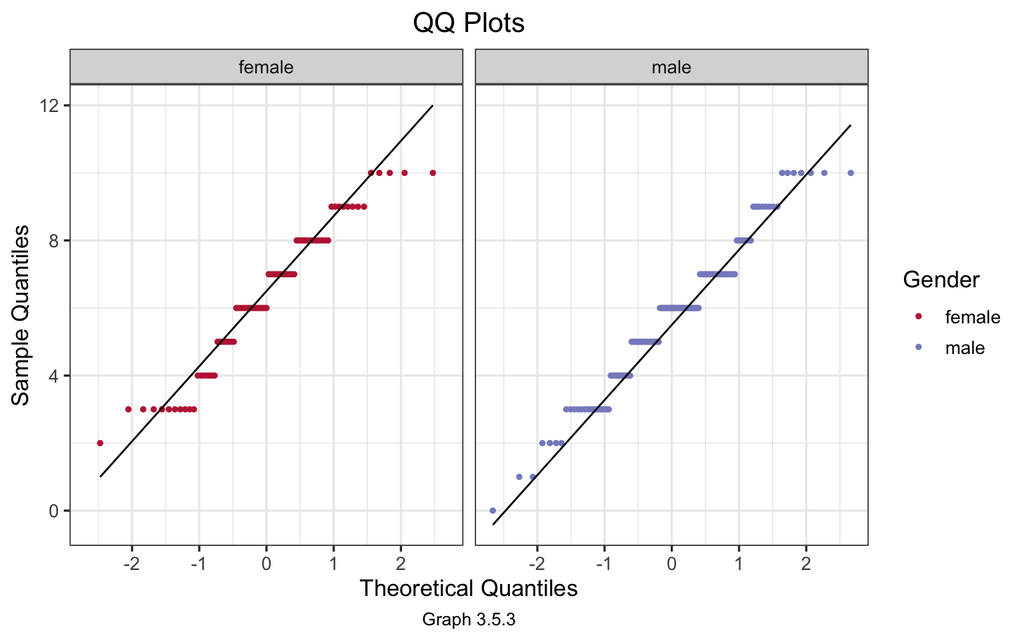

```r
# normality check
gender_stress %>% ggplot() +
  aes(sample = stress, color = gender) +
  geom_qq(size = 1) +
  geom_qq_line(color = "black") +
  labs(x = "Theoretical Quantiles", y = "Sample Quantiles", title = "QQ Plots",
       caption = "Graph 3.5.3", color = "Gender") +
  scale_color_manual(values = c("#BE2641", "#888CC7")) +
  theme_bw(base_size = 13) +
  theme(plot.title = element_text(hjust = 0.5),
        plot.caption = element_text(hjust = 0.5, size = 10)) +
  facet_wrap(~gender)
```

```r
# calculate average exercising hours per weekend across different stress category groups
stress_summary = gender_stress %>%
  group_by(gender) %>%
  summarize(Mean = mean(stress),
            SD = sd(stress),
            n = n())
knitr::kable(stress_summary, digits = 2, caption = "Table 3.5.2: Stress Score Statistics by Gender")
```

Table 3.5.2: Stress Score Statistics by Gender

| gender | Mean | SD | n |
| --- | --- | --- | --- |
| female | 6.36 | 2.14 | 75 |
| male | 5.72 | 2.14 | 129 |

```r
# given that the sample sizes of 76 and 129, the stress data for both genders are normally distributed (CLT)
# hence, perform a two-sample t-test (one-sided)
female_stress = (gender_stress %>%
  filter(gender == "female"))$stress

male_stress = (gender_stress %>%
  filter(gender == "male"))$stress

t.test(female_stress, male_stress, alternative = "greater", var.equal = TRUE)
```

```
##
##  Two Sample t-test
##
## data:  female_stress and male_stress
## t = 2.0564, df = 202, p-value = 0.02051
## alternative hypothesis: true difference in means is greater than 0
## 95 percent confidence interval:
##  0.1255429       Inf
## sample estimates:
## mean of x mean of y
##   6.36000   5.72093
```

# 4 Conclusion

In this data analysis project, we have analyzed the degrees of stress in various facets of features: year-of-study status, study locations, and gender. In all three analyses, we have rejected the null hypotheses, indicating that we have detected meaningful differences between different groups/statuses against null hypotheses.  
Our findings suggest that first-year university students are more likely to be stressed due to difficulties arising from adjustment to university life. Also, in this COVID-19 pandemic crisis, university students studying outside Australia are more likely to be stressed due to possible issues related to remote learning. Lastly, it appears that female students tend to be more stressed than male students.

Nonetheless, all three analyses require further in-depth studies, as our sample data have raised several questions as discussed in the introduction. Given that our sample data is not a random sample, it can never represent the whole group of Australian university students, the entire population of interest. Furthermore, since stress is a complicated factor that can never be measured by a single question, various and more comprehensive measurements of stress will enable us to derive more reliable and insightful conclusions about the entire population of interest.

# 5 References

Australian Government Department of Education, Skills and Employment. (2021). *International student data monthly summary*. https://internationaleducation.gov.au/research/international-student-data/Documents/MONTHLY%20SUMMARIES/2021/Jul%202021%20MonthlyInfographic.pdf

Clinciu, A. I. (2013). Adaptation and stress for the first year university students. *Procedia-Social and Behavioral Sciences*, 78, 718-722.

Elsalem, L., Al-Azzam, N., Jum’ah, A. A., Obeidat, N., Sindiani, A. M., & Kheirallah, K. A. (2020). Stress and behavioral changes with remote E-exams during the Covid-19 pandemic: A cross-sectional study among undergraduates of medical sciences. *Annals of Medicine and Surgery*, 60, 271-279.

Gao, W., Ping, S., & Liu, X. (2020). Gender differences in depression, anxiety, and stress among college students: a longitudinal study from China. *Journal of affective disorders*, 263, 292-300.

Savage, M. J., James, R., Magistro, D., Donaldson, J., Healy, L. C., Nevill, M., & Hennis, P. J. (2020). Mental health and movement behaviour during the COVID-19 pandemic in UK university students: Prospective cohort study. *Mental Health and Physical Activity*, 19, 100357.